# DATA606 Lab4: The Normal Distribution

Sean Connin

03/02/21

In this lab, you’ll investigate the probability distribution that is most central to statistics: the normal distribution. If you are confident that your data are nearly normal, that opens the door to many powerful statistical methods. Here we’ll use the graphical tools of R to assess the normality of our data and also learn how to generate random numbers from a normal distribution.

## Getting Started

### Load packages

In this lab, we will explore and visualize the data using the **tidyverse** suite of packages as well as the **openintro** package.

Let’s load the packages.

```r
library(tidyverse)
library(openintro)
```

### The data

This week you’ll be working with fast food data. This data set contains data on 515 menu items from some of the most popular fast food restaurants worldwide. Let’s take a quick peek at the first few rows of the data.

Either you can use `glimpse` like before, or `head` to do this.

```r
library(tidyverse)
library(openintro)


data("fastfood", package='openintro')
head(fastfood)
```

```
## # A tibble: 6 x 17
##   restaurant item       calories cal_fat total_fat sat_fat trans_fat cholesterol
##   <chr>      <chr>         <dbl>   <dbl>     <dbl>   <dbl>     <dbl>       <dbl>
## 1 Mcdonalds  Artisan G~      380      60         7       2       0            95
## 2 Mcdonalds  Single Ba~      840     410        45      17       1.5         130
## 3 Mcdonalds  Double Ba~     1130     600        67      27       3           220
## 4 Mcdonalds  Grilled B~      750     280        31      10       0.5         155
## 5 Mcdonalds  Crispy Ba~      920     410        45      12       0.5         120
## 6 Mcdonalds  Big Mac         540     250        28      10       1            80
## # ... with 9 more variables: sodium <dbl>, total_carb <dbl>, fiber <dbl>,
## #   sugar <dbl>, protein <dbl>, vit_a <dbl>, vit_c <dbl>, calcium <dbl>,
## #   salad <chr>
```

You’ll see that for every observation there are 17 measurements, many of which are nutritional facts.

You’ll be focusing on just three columns to get started: restaurant, calories, calories from fat.

Let’s first focus on just products from McDonalds and Dairy Queen.

```r
mcdonalds <- fastfood %>%
  filter(restaurant == "Mcdonalds")


dairy_queen <- fastfood %>%
  filter(restaurant == "Dairy Queen")
```

1. Make a plot (or plots) to visualize the distributions of the amount of calories from fat of the options from these two restaurants. How do their centers, shapes, and spreads compare?

*The distributions for cal_fat from McDonalds (mean = 286) and Dairy Queen (mean=260) menu items are similar about their center.*

*Both distributions are unimodal and skew to the right; the extent of skew is more pronounced for the McDonalds data. This is evident in the range of values for cal_fat from Dairy Queen menu items (0-670) vs. those from McDonalds (50-1270).*

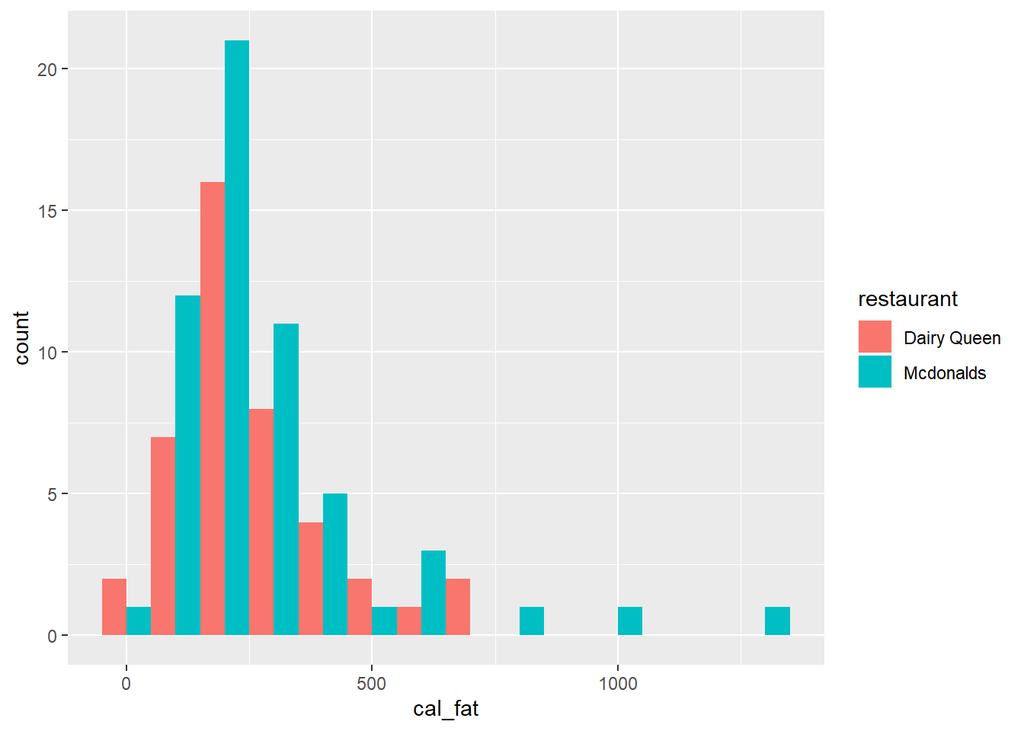

```r
# Select restaurants and calories from fat for plotting

cal<-mcdonalds%>%rbind(dairy_queen)%>%select(restaurant, cal_fat)

# Plot histogram overlay for restaurants

ggplot(cal, aes(x=cal_fat, fill=restaurant)) + geom_histogram(binwidth=100.0, position="dodge")
```

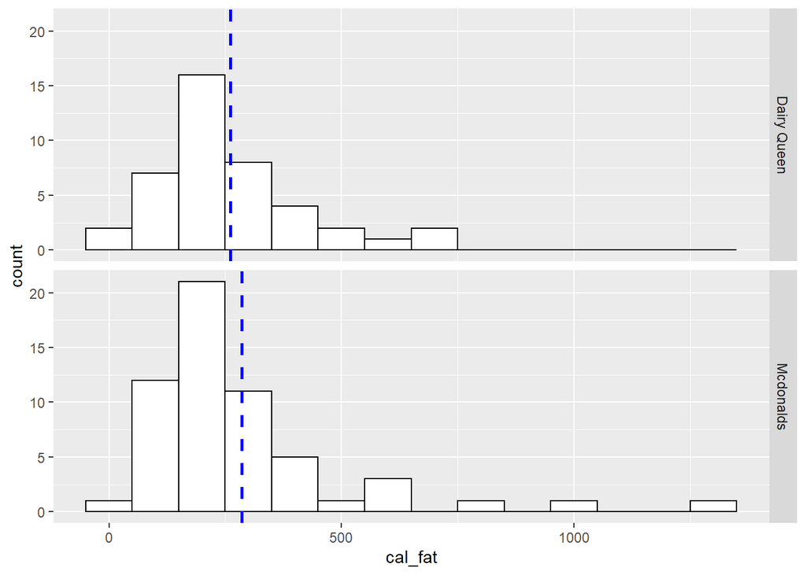

```r
# Find the mean of fat_cal for each restaurant

avg <- cal%>%group_by(restaurant)%>%summarize(mean=mean(cal_fat), range=range(cal_fat))

# Plot with means and faceting
ggplot(cal, aes(x=cal_fat)) + geom_histogram(binwidth=100, colour="black", fill="white") +
    facet_grid(restaurant ~ .) +
    geom_vline(data=avg, aes(xintercept=mean),
    linetype="dashed", size=1, colour="blue")
```

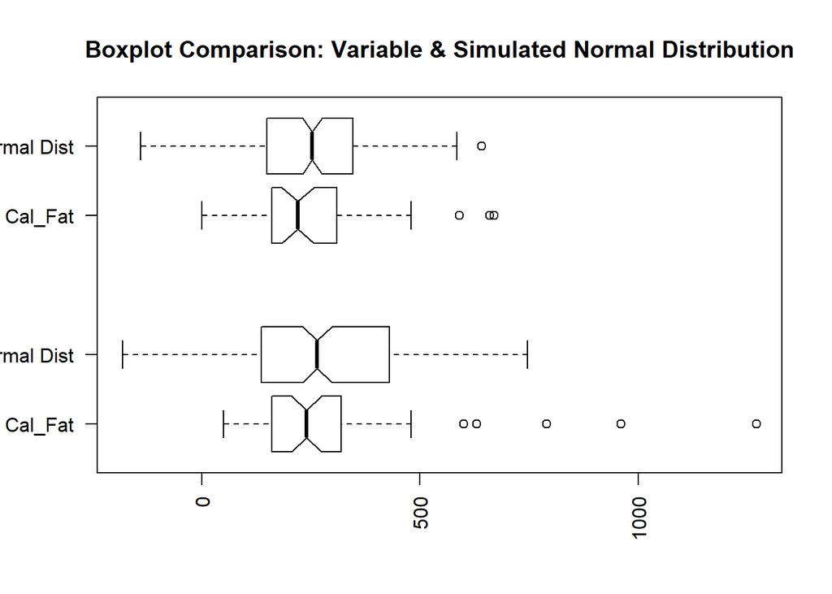

```r
# Plot variable distributions and simulated normal distributions as boxplots. Adapted from https://www.datamentor.io/r-programming/box-plot/

mfat <- mcdonalds$cal_fat
dfat <- dairy_queen$cal_fat

# generate normal distribution with same mean and sd
mfat_norm <- rnorm(200,mean=mean(mfat, na.rm=TRUE), sd=sd(mfat, na.rm=TRUE))
dfat_norm <- rnorm(200,mean=mean(dfat, na.rm=TRUE), sd=sd(dfat, na.rm=TRUE))

boxplot(mfat, mfat_norm, dfat, dfat_norm,
main = "Boxplot Comparison: Variable & Simulated Normal Distribution",
at = c(1,2,4,5),
names = c("Mcdonalds Cal_Fat", "Normal Dist", "Dairy Queen Cal_Fat", "Normal Dist"),
las = 2,
col = c("white","white"),
border = "black",
horizontal = TRUE,
notch = TRUE)
```